# Assignment 1

California Spiny Lobster (*Panulirus Interruptus*): Assessing the Impact of Marine Protected Areas (MPAs) at 5 Reef Sites in Santa Barbara County

Megan Hessel

1/8/26

### Assignment Instructions:

- Working with partners to troubleshoot code and concepts is encouraged! If you work with a partner, please list their name next to yours at the top of your assignment so Annie and I can easily see who collaborated.
- All written responses must be written independently (**in your own words**).
- Please follow the question prompts carefully and include only the information each question asks in your submitted responses.
- Submit both your knitted document and the associated `RMarkdown` or `Quarto` file.
- Your knitted presentation should meet the quality you’d submit to research colleagues or feel confident sharing publicly. Refer to the rubric for details about presentation standards.

**Assignment submission:** Megan Hessel

```r
library(tidyverse)
library(here)
library(janitor)
library(estimatr)
library(performance)
library(jtools)
library(gt)
library(gtsummary)
library(interactions)
library(dplyr)
library(ggridges)
library(paletteer)
library(gtsummary)
library(gt)
library(MASS)
```

#### DATA SOURCE:

> [Reed D. 2019. SBC LTER: Reef: Abundance, size and fishing effort for California Spiny Lobster (Panulirus interruptus), ongoing since 2012. Environmental Data Initiative.](https://doi.org/10.6073/pasta/a593a675d644fdefb736750b291579a0) Data accessed 11/17/2019.

### **Introduction**

You’re about to dive into some deep data collected from five reef sites in Santa Barbara County, all about the abundance of California spiny lobsters! 🦞 Data was gathered by divers annually from 2012 to 2018 across Naples, Mohawk, Isla Vista, Carpinteria, and Arroyo Quemado reefs.

Why lobsters? Well, this sample provides an opportunity to evaluate the impact of Marine Protected Areas (MPAs) established on January 1, 2012 (Reed, 2019). Of these five reefs, *Naples, and Isla Vista are MPAs,* while the other three are not protected (non-MPAs). Comparing lobster health between these protected and non-protected areas gives us the chance to study how commercial and recreational fishing might impact these ecosystems.

We will consider the MPA sites the `treatment` group and use regression methods to explore whether protecting these reefs really makes a difference compared to non-MPA sites (our control group). In this assignment, we’ll think deeply about which causal inference assumptions hold up under the research design and identify where they fall short.

Let’s break it down step by step and see what the data reveals! 📊

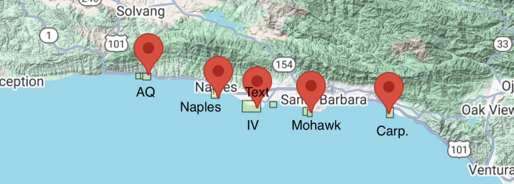

#### Step 1: Anticipating potential sources of selection bias

**a.** Do the control sites (Arroyo Quemado, Carpenteria, and Mohawk) provide a strong counterfactual for our treatment sites (Naples, Isla Vista)? Write a paragraph making a case for why this comparison is ceteris paribus or whether selection bias is likely (be specific!).

There is some selection bias due to the sites’ differing in several ways, such as current intensity and patterns, anthropomorphic activity, and temperature. Point Conception (which is just West of this map) is where the cold, subarctic Northern California current and warm Southern California current meet, creating upwhelling. Therefore, Eastern sites might be warmer and facing more current strength than the Western sites due to the mixing and upwhelling West of Santa Barbara. Additionally, Naples, IV, and Monhawk are closer to the city, possibly facing more pollution and disturbance. Furthermore, Naples and Isla Vista were given MPA status in January 2012 by the California Department of Fish and Game. These site locations are purposely selected in order to help conservation efforts in Santa Barbara fisheries. Therefore, these control and treatment sites are not *ceters paribus* as they may face different abiotic and biotic pressures and are not randomly selected. These various confounding variables mean the control group is not a good counterfactual.

While sites differ on several confounding variables, these sites selections are still useful to study and close to ceters paribus. Control groups are both east and west of the treatment group, minimizing the effect of the different current and temperature pressures. All sites are very close to Santa Barbara. Due to aquatic system’s spatial autocorrelation, pollution in one location will most likely be in other locations. Therefore, in this example, there is selection bias, but locations face similar conditions (except MPA status) which make this research helpful in understanding impact of MPAs on California Spiny Lobster (*Panulirus Interruptus*).

#### Step 2: Read & wrangle data

**a.** Read in the raw data from the “data” folder named `spiny_abundance_sb_18.csv`. Name the data.frame `rawdata`

**b.** Use the function `clean_names()` from the `janitor` package

```r
# HINT: check for coding of missing values (`na = "-99999"`)

rawdata <- read_csv(here::here("data", "spiny_abundance_sb_18.csv"),
                    na = '-99999') %>% # converting '-9999' values to NA
    janitor::clean_names()
```

**c.** Create a new `df` named `tidyata`. Using the variable `site` (reef location) create a new variable `reef` as a `factor` and add the following labels in the order listed (i.e., re-order the `levels`):

```
"Arroyo Quemado", "Carpenteria", "Mohawk", "Isla Vista",  "Naples"
```

```r
# Creating the ordered wanted
custom_order <- c("Arroyo Quemado", "Carpenteria", "Mohawk", "Isla Vista", "Naples")

# Making a `reef` a factor from `site` col
tidydata <- rawdata %>%
    mutate(reef = factor(rawdata$site, levels = c("AQUE", "CARP", "MOHK", "IVEE","NAPL"), labels = custom_order))


# Checking the level order
levels(tidydata$reef)
```

```
## [1] "Arroyo Quemado" "Carpenteria"    "Mohawk"         "Isla Vista"
## [5] "Naples"
```

Create new `df` named `spiny_counts`

**d.** Create a new variable `counts` to allow for an analysis of lobster counts where the unit-level of observation is the total number of observed lobsters per `site`, `year` and `transect`.

- Create a variable `mean_size` from the variable `size_mm`
- NOTE: The variable `counts` should have values which are integers (whole numbers).
- Make sure to account for missing cases (`na`)!

```r
#HINT(d): Use `group_by()` & `summarize()` to provide the total number of lobsters observed at each site-year-transect row-observation.

spiny_counts <- tidydata %>%
    group_by(site, year, transect) %>%
    summarise(obs_lob = sum(count, na.rm = TRUE), # Number of lobsters observed
              mean_size = mean(size_mm, na.rm = TRUE)) %>%
    ungroup()
# `count` = Total number of lobsters of this size in the lobster transect
# `num_ao` = Number of lobster that only its antenna was visible
```

**e.** Create a new variable `mpa` with levels `MPA` and `non_MPA`. For our regression analysis create a numerical variable `treat` where MPA sites are coded `1` and non_MPA sites are coded `0`

```r
#HINT(e): Use `case_when()` to create the 3 new variable columns

spiny_counts <- spiny_counts %>%
    mutate(mpa = case_when(
        site == 'AQUE' | site == 'CARP' | site == 'MOHK'  ~ 'non_MPA', # non MPA sites
        site == 'IVEE' | site == 'NAPL' ~ 'MPA' # MPA sites
))

# Making `mpa` and `treat` a factor with 0 / non_MPA and 1 / MPA
custom_order <- c("non_MPA", "MPA")
#spiny_counts$mpa <- factor(spiny_counts$mpa, levels = custom_order)
spiny_counts$treat <- factor(spiny_counts$mpa, levels = custom_order, labels = c(0, 1))

# Checking levels of factors
#levels(spiny_counts$mpa)
levels(spiny_counts$treat)
```

```
## [1] "0" "1"
```

> NOTE: This step is crucial to the analysis. Check with a friend or come to TA/instructor office hours to make sure the counts are coded correctly!

#### Step 3: Explore & visualize data

**a.** Take a look at the data! Get familiar with the data in each `df` format (`tidydata`, `spiny_counts`)

```r
str(tidydata)
```

```
## tibble [4,362 × 11] (S3: tbl_df/tbl/data.frame)
##  $ year     : num [1:4362] 2012 2012 2012 2012 2012 ...
##  $ month    : num [1:4362] 8 8 8 8 8 8 8 8 8 8 ...
##  $ date     : Date[1:4362], format: "2012-08-20" "2012-08-20" ...
##  $ site     : chr [1:4362] "IVEE" "IVEE" "IVEE" "IVEE" ...
##  $ transect : num [1:4362] 1 1 1 1 2 2 2 2 3 3 ...
##  $ replicate: chr [1:4362] "A" "B" "C" "D" ...
##  $ size_mm  : num [1:4362] NA NA NA NA NA NA NA NA 70 60 ...
##  $ count    : num [1:4362] 0 0 0 0 0 0 0 0 1 1 ...
##  $ num_ao   : num [1:4362] 0 0 0 0 0 0 0 0 0 0 ...
##  $ area     : num [1:4362] 300 300 300 300 300 300 300 300 300 300 ...
##  $ reef     : Factor w/ 5 levels "Arroyo Quemado",..: 4 4 4 4 4 4 4 4 4 4 ...
```

```r
str(spiny_counts)
```

```
## tibble [252 × 7] (S3: tbl_df/tbl/data.frame)
##  $ site     : chr [1:252] "AQUE" "AQUE" "AQUE" "AQUE" ...
##  $ year     : num [1:252] 2012 2012 2012 2012 2012 ...
##  $ transect : num [1:252] 1 2 3 4 5 6 7 1 2 3 ...
##  $ obs_lob  : num [1:252] 5 9 0 9 11 0 4 7 2 0 ...
##  $ mean_size: num [1:252] 64.2 66 NaN 74.1 76.9 ...
##  $ mpa      : chr [1:252] "non_MPA" "non_MPA" "non_MPA" "non_MPA" ...
##  $ treat    : Factor w/ 2 levels "0","1": 1 1 1 1 1 1 1 1 1 1 ...
```

**b.** We will focus on the variables `count`, `year`, `site`, and `treat`(`mpa`) to model lobster abundance. Create the following 4 plots using a different method each time from the 6 options provided. Add a layer (`geom`) to each of the plots including informative descriptive statistics (you choose; e.g., mean, median, SD, quartiles, range). Make sure each plot dimension is clearly labeled (e.g., axes, groups).

- [Density plot](https://r-charts.com/distribution/density-plot-group-ggplot2)
- [Ridge plot](https://r-charts.com/distribution/ggridges/)
- [Jitter plot](https://ggplot2.tidyverse.org/reference/geom_jitter.html)
- [Violin plot](https://r-charts.com/distribution/violin-plot-group-ggplot2)
- [Histogram](https://r-charts.com/distribution/histogram-density-ggplot2/)
- [Beeswarm](https://r-charts.com/distribution/beeswarm/)

Create plots displaying the distribution of lobster **counts**:

1. grouped by reef site

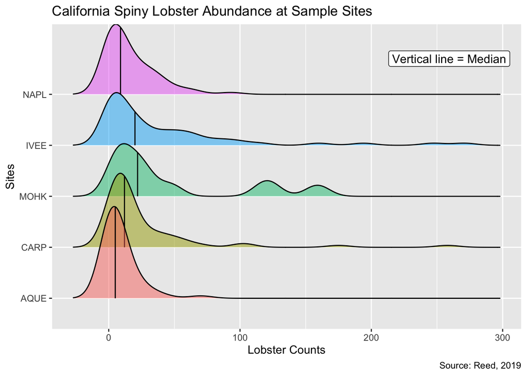

```r
color_palette <- c('#0a6664', '#17BEBBFF', '#D4F4DDFF', '#D62246FF', '#4B1D3FFF')

# Density graph by reef site
spiny_counts %>%
    mutate(site = factor(site,
                         levels = c("AQUE", "CARP", "MOHK", "IVEE","NAPL")
                         )) %>%
    ggplot(aes(x = obs_lob, y = site, fill = site)) +
    geom_density_ridges( alpha = 0.5,
                         quantile_lines = TRUE, # draw vertical lines at quantile positions
                         quantiles = 2 # median split
                         ) +
    theme_gray() +
    labs(x = "Lobster Counts",
         y = "Sites",
         title = "California Spiny Lobster Abundance at Sample Sites",
         caption = "Source: Reed, 2019") +
    #scale_fill_manual(values = color_palette) +
    theme(legend.position="none") +
    annotate("label",
    x = 0.8, y = 5.7,        # position of the annotation
    label = "Vertical line = Median",
    hjust = -2.3,
    size = 4,
    color = "black"
  )
```

2. grouped by MPA status

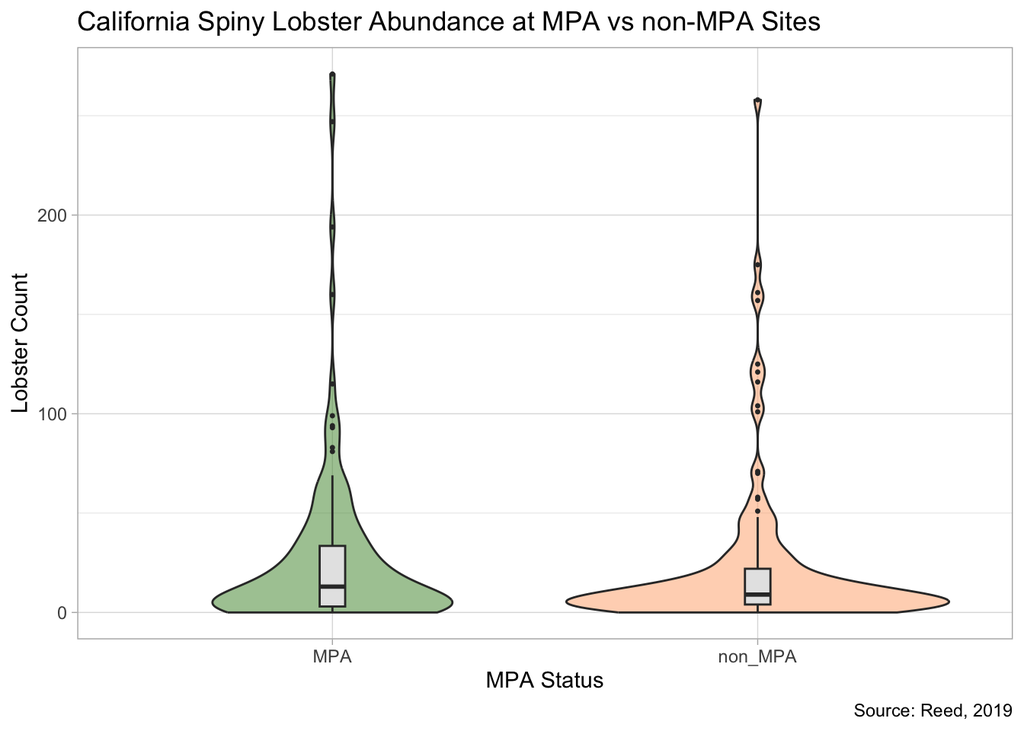

```r
ggplot(spiny_counts, aes(x = mpa, y = obs_lob, fill = mpa)) +
    geom_violin(alpha = 0.5) +
    scale_fill_manual(values = c('#488f30', '#ffad76')) +
    theme_light() +
    theme(legend.position="none") +
    labs(x = 'MPA Status',
         y = 'Lobster Count',
         title = 'California Spiny Lobster Abundance at MPA vs non-MPA Sites',
         caption = "Source: Reed, 2019") +
    geom_boxplot(width = 0.06,
                 outlier.size = 0.55,
                 fill = "grey90")
```

3. grouped by year

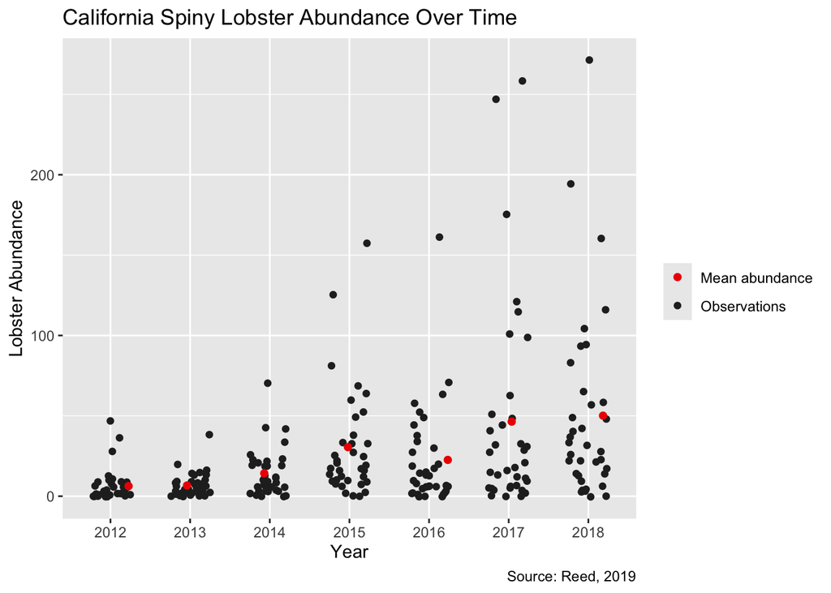

```r
spiny_summary <- spiny_counts %>%
    group_by(year) %>%
    summarise(mean_count = mean(obs_lob))


ggplot() +
  geom_jitter(data = spiny_counts,
    mapping = aes(x = factor(year), y = obs_lob,
        color = "Observations"),
    width = 0.25) +
  geom_jitter(data = spiny_summary,
    mapping = aes(x = factor(year), y = mean_count,
        color = "Mean abundance"),
    width = 0.25,
    size = 1.7) +
  scale_color_manual(
    name = "",
    values = c(
      "Observations" = "grey15",
      "Mean abundance" = "red2")) +
  labs(
    x = "Year",
    y = "Lobster Abundance",
    title = "California Spiny Lobster Abundance Over Time",
    caption = "Source: Reed, 2019") +
  theme_grey()
```

Create a plot of lobster **size** :

4. You choose the grouping variable(s)!

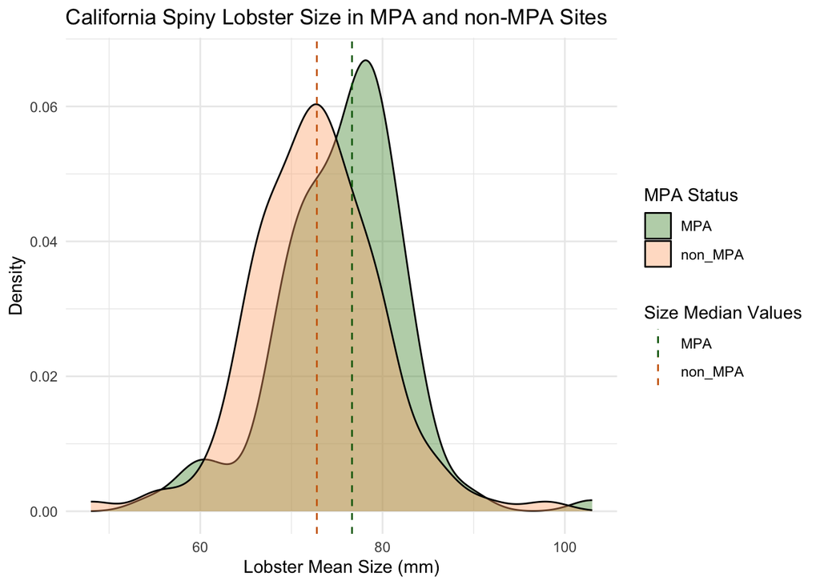

```r
# Calculate median
median_group <- spiny_counts %>%
    group_by(mpa) %>%
    summarise(median = median(mean_size, na.rm = TRUE, .group = drop))

# Plot with medians
ggplot() +
    geom_density(
        data = spiny_counts,
        mapping = aes(x = mean_size, fill = mpa),
        alpha = 0.4) +
    theme_minimal() +
    geom_vline(data = median_group,
        mapping = (aes(xintercept = median,
                       color = mpa)),
        linetype = "dashed") +
    scale_color_manual(values = c("darkgreen", "darkorange3"))+
    scale_fill_manual(values = c("#488f30", "#ffad76")) +
    labs(x = "Lobster Mean Size (mm)",
         y = "Density",
         title = "California Spiny Lobster Size in MPA and non-MPA Sites",
         fill = "MPA Status",
         color = "Size Median Values")
```

**c.** Compare means of the outcome by treatment group. Using the `tbl_summary()` function from the package [`gt_summary`](https://www.danieldsjoberg.com/gtsummary/articles/tbl_summary.html)

```r
spiny_counts %>%
    rename(lobster_count = obs_lob) %>%
    gtsummary::tbl_summary(
        by = treat,
        include = c(lobster_count, mean_size, site),
        statistic = list(all_continuous() ~ '{mean} ({sd})')
    ) %>%
    add_p() %>%
    # Add header labels
    modify_header(label ~ "**Variable**") %>%
    modify_spanning_header(c("stat_1", "stat_2") ~ "**Treatment**")
```

[output not shown]

<sup>1</sup> Mean (SD); n (%)  
<sup>2</sup> Wilcoxon rank sum test; Pearson’s Chi-squared test

#### Step 4: OLS regression- building intuition

**a.** Start with a simple OLS estimator of lobster counts regressed on treatment. Use the function `summ()` from the [`jtools`](https://jtools.jacob-long.com/) package to print the OLS output

**b.** Interpret the intercept & predictor coefficients *in your own words*. Use full sentences and write your interpretation of the regression results to be as clear as possible to a non-academic audience.

```r
# NOTE: We will not evaluate/interpret model fit in this assignment (e.g., R-square)

m1_ols <- lm(obs_lob ~ treat, data = spiny_counts)

summ(m1_ols, model.fit = FALSE)
```

| Observations | 252 |
| --- | --- |
| Dependent variable | obs_lob |
| Type | OLS linear regression |

|  | Est. | S.E. | t val. | p |
| --- | --- | --- | --- | --- |
| (Intercept) | 22.73 | 3.57 | 6.36 | 0.00 |
| treat1 | 5.36 | 5.20 | 1.03 | 0.30 |

Standard errors: OLS

*Intercept:* With no treatment (in a non-MPA site), there is expected to be an average of ~22.75 lobsters.

*Coefficient Estimation:* With treatment (MPA protection), lobsters count is expected to increase by approximately 5.36 lobsters.

**c.** Check the model assumptions using the `check_model` function from the `performance` package

**d.** Explain the results of the 4 diagnostic plots. Why are we getting this result?

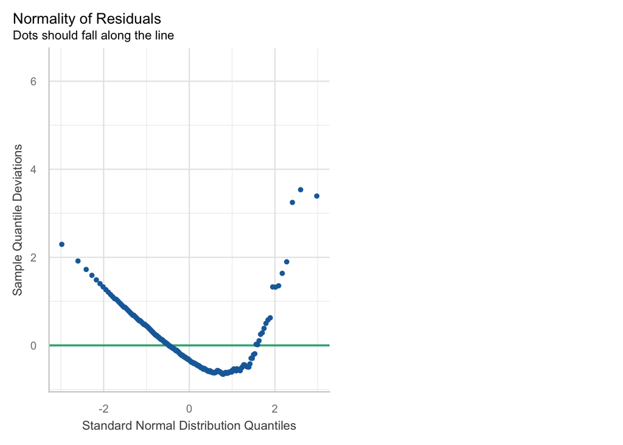

```r
check_model(m1_ols,  check = "qq" )
```

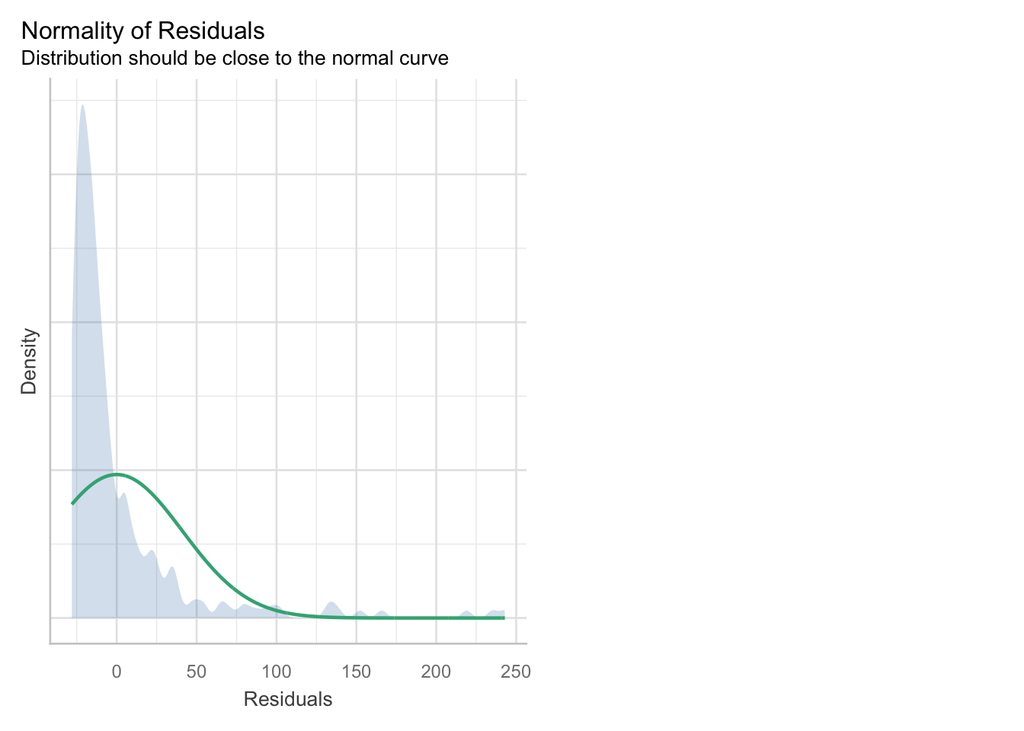

```r
check_model(m1_ols, check = "normality")
```

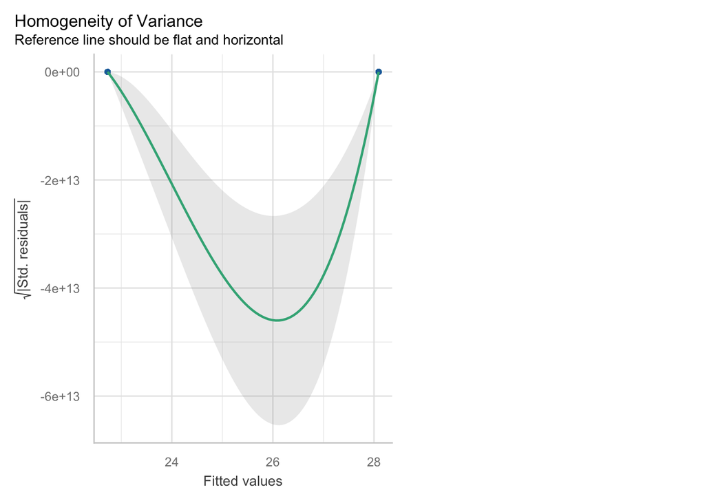

```r
check_model(m1_ols, check = "homogeneity")
```

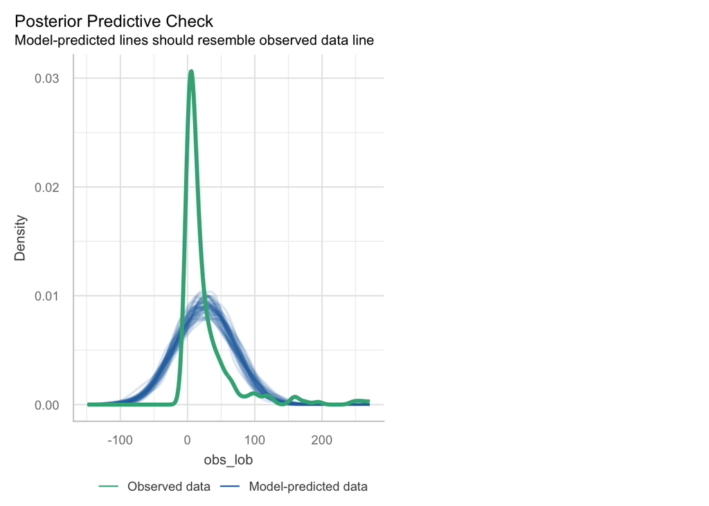

```r
check_model(m1_ols, check = "pp_check")
```

By the `check_model` graphs, the data is not normality distributed (with a leptokurtic skewed distribution), the residuals are not normality distribution, and there is no equal variance (heteroscedasticity). The `check_model` results are showing the data’s inherently skewed characteristic. These violate OSL model’s assumptions.

#### Step 5: Fitting GLMs

**a.** Estimate a *Poisson regression model* using the `glm()` function

**b.** Interpret the predictor coefficient in your own words. Use full sentences and write your interpretation of the results to be as clear as possible to a non-academic audience.

*Intercept:* exp(3.12) = 22.64638 *Est coefficient:* exp(0.21) = 1.233678 With no treatment (non-MPA locations), the lobster count is expected to be ~23 on average. With treatment (MPA protection), lobster count is expected to increase by 23% which is statistically significant.

**c.** Explain the statistical concept of dispersion and overdispersion in the context of this model.

Dispersion is when the mean and variance are similar in portion to each other. Overdispersion is when there is greater variance than expected and thus not proportional to the mean. Poisson is a statistical test where mean and variance must be proportional; overdispersion in Poisson can cause misleading test statistics and standard errors. A dispersion ratio of 67.033 indicates overdispersion which violates the Poisson assumption.

**d.** Compare results with previous model, explain change in the significance of the treatment effect

Both models have similar predictions. However, in the OSL model, there is no statistical significance in lobster counts between MPA and non-MPA sites. In the Poisson model, there is a statistical significance in lobster abundance between treatments. The Poisson model is better fitted for count data, and therefore give more accurate results.

**e.** Check the model assumptions. Explain results.

This data have overdispersion (dispersion ration of 67.033) and zero-inflation (27 observed zeros) which breaks Poisson model assumptions. Therefore, the Poisson model is inappropriate for this data set.

**f.** Conduct tests for over-dispersion & zero-inflation. Explain results.

```r
# Poisson model

m2_pois <- glm(obs_lob ~ treat, data = spiny_counts, family = poisson(link = "log"))

summ(m2_pois, model.fit = FALSE)
```

| Observations | 252 |
| --- | --- |
| Dependent variable | obs_lob |
| Type | Generalized linear model |
| Family | poisson |
| Link | log |

|  | Est. | S.E. | z val. | p |
| --- | --- | --- | --- | --- |
| (Intercept) | 3.12 | 0.02 | 171.74 | 0.00 |
| treat1 | 0.21 | 0.03 | 8.44 | 0.00 |

Standard errors: MLE

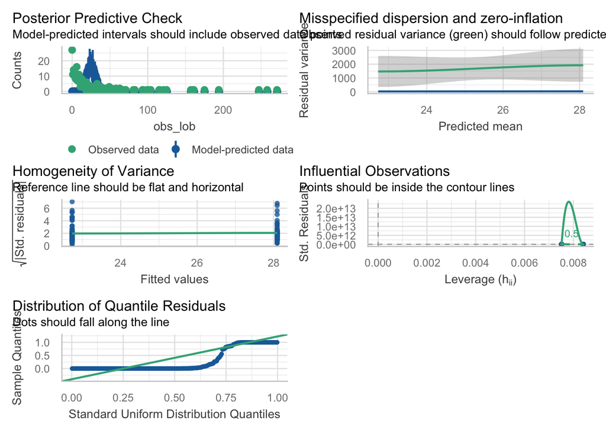

```r
# Checking assumptions
check_model(m2_pois)
```

```r
check_overdispersion(m2_pois)
```

```
## # Overdispersion test
##
##        dispersion ratio =    67.033
##   Pearson's Chi-Squared = 16758.289
##                 p-value =   < 0.001
```

```
## Overdispersion detected.
```

```r
check_zeroinflation(m2_pois)
```

```
## # Check for zero-inflation
##
##    Observed zeros: 27
##   Predicted zeros: 0
##             Ratio: 0.00
```

```
## Model is underfitting zeros (probable zero-inflation).
```

**g.** Fit a *negative binomial model* using the function glm.nb() from the package `MASS` and check model diagnostics

**h.** In 1-2 sentences explain rationale for fitting this GLM model.

Negative binomial model is more flexible than the Poisson model because it accounts for overdispersion by adding a dispersion parameter. Because this data has overdispersion, it is more appropriately fitted for the negative binomial model.

**i.** Interpret the treatment estimate result in your own words. Compare with results from the previous model.

exp(3.12) = 22.64638 exp(0.21) = 1.233678

In not protected areas, the expected lobster count is ~23 on average. In MPA sites, there is a expected increase of 23% lobsters, but this relationships is not significant.

All models suggest lobster abundance is higher in Marine Protected Areas (MPAs). Specifically, the estimations from the poisson and negative binomial models are very similar. The P-values are the main difference between the models. Poisson shows statistical significance while the negative binomal model and linear regression does not. The Poission P-value result should be treated with caution because the assumptions for Poisson are violated which can lead to misleading P-values. Similarly, the linear regession assumptions are violated which can cause unreliable results.

```r
# Negative Binomal
m3_nb <- glm.nb(obs_lob ~ treat, data = spiny_counts) # `glm.nb()`  does not require a `family` argument

summ(m3_nb, model.fit = FALSE)
```

| Observations | 252 |
| --- | --- |
| Dependent variable | obs_lob |
| Type | Generalized linear model |
| Family | Negative Binomial(0.55) |
| Link | log |

|  | Est. | S.E. | z val. | p |
| --- | --- | --- | --- | --- |
| (Intercept) | 3.12 | 0.12 | 26.40 | 0.00 |
| treat1 | 0.21 | 0.17 | 1.23 | 0.22 |

Standard errors: MLE

```r
check_overdispersion(m3_nb)
```

```
## # Overdispersion test
##
##  dispersion ratio = 1.398
##           p-value = 0.088
```

```
## No overdispersion detected.
```

```r
check_zeroinflation(m3_nb)
```

```
## # Check for zero-inflation
##
##    Observed zeros: 27
##   Predicted zeros: 30
##             Ratio: 1.12
```

```
## Model is overfitting zeros (p = 0.600).
```

```r
check_predictions(m3_nb)
```

```
## Ignoring unknown labels:
## • size : ""
## • alpha : ""
```

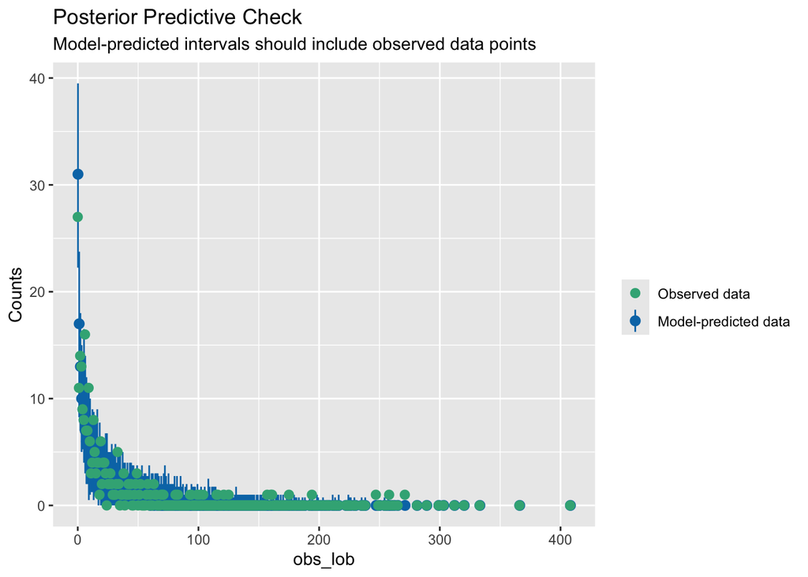

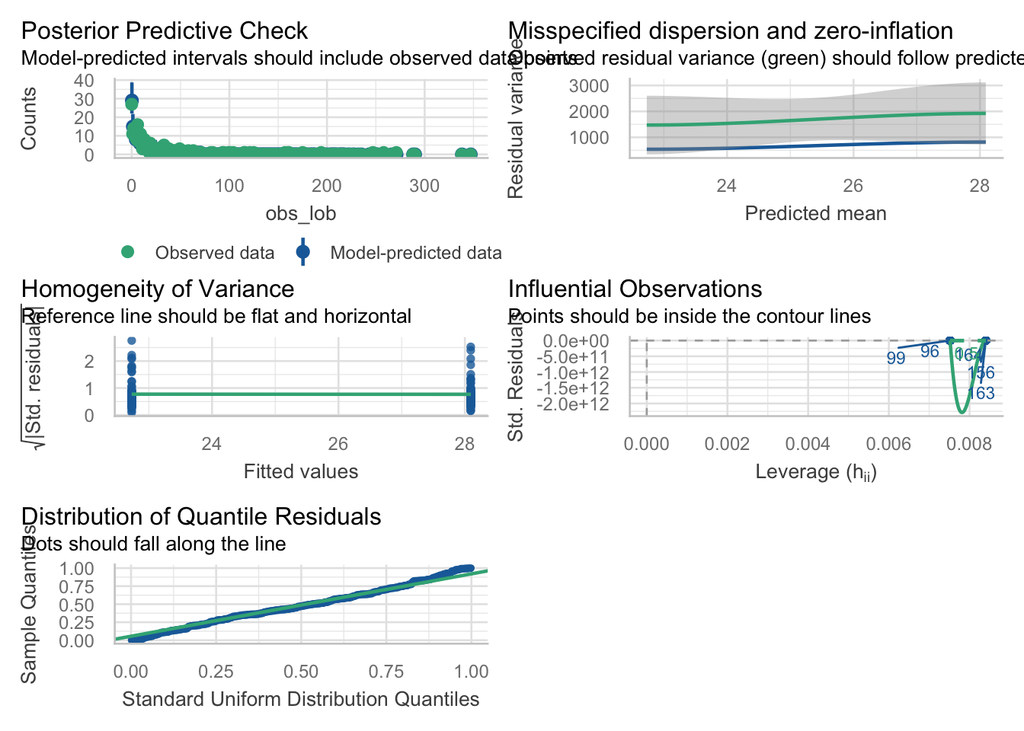

```r
check_model(m3_nb)
```

#### Step 6: Compare models

**a.** Use the `export_summ()` function from the `jtools` package to look at the three regression models you fit side-by-side.

**c.** Write a short paragraph comparing the results. Is the treatment effect `robust` or stable across the model specifications.

In all three models, the treatment coefficient is positive, meaning there is an increases of lobster abundance in the treatment sites (MPAs) compared to the untreated (unprotected) areas. Additionally, the estimates themselves were all very similar between models. The primary distinctions between the models are the P-values and standard deviations. The OLS model shows high uncertainty in its positive prediction and no statistical significance. The OLS is a poor model for the count dataset, seen by the high uncertainty. The Poisson model’s P-value shows statistical significance. However, the over-dispersion and zero-inflated nature of the count data makes Poisson an inadequate model. Lastly, the negative binomial accounts for over-dispersion and zero values, making the model a more appropriate fit. The negative binomial model estimates a positive treatment effect, but no statistical significance. In conclusion, the estimates are all consistent. However, statistical significance is not robust across all the models specifications.

```r
export_summs(m1_ols, m2_pois, m3_nb,
             model.names = c("OLS","Poisson", "NB"),
             statistics = "none")
```

|  | OLS | Poisson | NB |
| --- | --- | --- | --- |
| (Intercept) | 22.73 *** | 3.12 *** | 3.12 *** |
|  | (3.57) | (0.02) | (0.12) |
| treat1 | 5.36 | 0.21 *** | 0.21 |
|  | (5.20) | (0.03) | (0.17) |
| *** p < 0.001; ** p < 0.01; * p < 0.05. |  |  |  |

#### Step 7: Building intuition - fixed effects

**a.** Create new `df` with the `year` variable converted to a factor

**b.** Run the following negative binomial model using `glm.nb()`

- Add fixed effects for `year` (i.e., dummy coefficients)
- Include an interaction term between variables `treat` & `year` (`treat*year`)

**c.** Take a look at the regression output. Each coefficient provides a comparison or the difference in means for a specific sub-group in the data. Informally, describe the what the model has estimated at a conceptual level (NOTE: you do not have to interpret coefficients individually)

By adding `year` as an additive and multiplicative variable, we are now examining the change of lobster counts in MPA vs non-MPA sites *overtime*. The reference year is 2012. The year coefficients are the expected average change of lobster abundance from 2012 in unprotected sites. The `treat` coefficient explains the expected change of lobster abundance between treatment (MPAs) and non-treatment (non-MPA) sites - the effect of the treatment. The interaction between the predictors examines if lobster counts in MPAs are changing relative to non-MPA sites in each year.

**d.** Explain why the main effect for treatment is negative? *Does this result make sense?

The treatment coefficient examines the change of lobster counts when the year is fixed (fixed to the reference year - 2012). The results show, in 2012, the MPA sites had on average 82% less lobsters than the non-MPA sites. MPA lobster abundance increases in the later years which is seen in the interaction terms, not the treatment coefficient. These results make sense as MPA are designed to increase biodiversity overtime.

```r
ff_counts <- spiny_counts %>%
    mutate(year=as_factor(year))

m5_fixedeffs <- glm.nb(
    obs_lob ~
        treat +
        year +
        treat*year,
    data = ff_counts)

summ(m5_fixedeffs, model.fit = FALSE)
```

| Observations | 252 |
| --- | --- |
| Dependent variable | obs_lob |
| Type | Generalized linear model |
| Family | Negative Binomial(0.8129) |
| Link | log |

|  | Est. | S.E. | z val. | p |
| --- | --- | --- | --- | --- |
| (Intercept) | 2.35 | 0.26 | 8.89 | 0.00 |
| treat1 | -1.72 | 0.42 | -4.12 | 0.00 |
| year2013 | -0.35 | 0.38 | -0.93 | 0.35 |
| year2014 | 0.08 | 0.37 | 0.21 | 0.84 |
| year2015 | 0.86 | 0.37 | 2.32 | 0.02 |
| year2016 | 0.90 | 0.37 | 2.43 | 0.01 |
| year2017 | 1.56 | 0.37 | 4.25 | 0.00 |
| year2018 | 1.04 | 0.37 | 2.81 | 0.00 |
| treat1:year2013 | 1.52 | 0.57 | 2.66 | 0.01 |
| treat1:year2014 | 2.14 | 0.56 | 3.80 | 0.00 |
| treat1:year2015 | 2.12 | 0.56 | 3.79 | 0.00 |
| treat1:year2016 | 1.40 | 0.56 | 2.50 | 0.01 |
| treat1:year2017 | 1.55 | 0.56 | 2.77 | 0.01 |
| treat1:year2018 | 2.62 | 0.56 | 4.69 | 0.00 |

Standard errors: MLE

**e.** Look at the model predictions: Use the `interact_plot()` function from package `interactions` to plot mean predictions by year and treatment status.

**f.** Re-evaluate your responses (c) and (b) above.

My previous explanation of the terms is exemplified in the `interact_plot()`. In 2012 (the reference year), MPA sites had considerably less lobster abundance. As time continued, lobster counts increased overall, especially in treatment/protected areas (with a drop in the population in 2016 at MPA sites).

[output not shown]

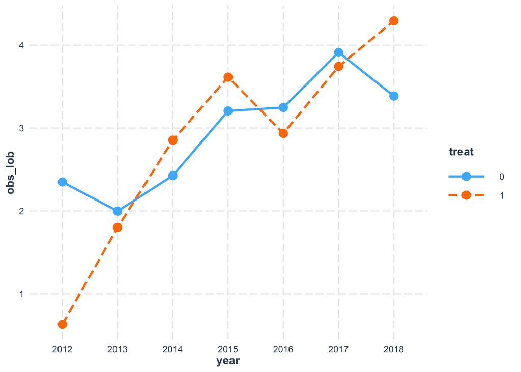

```r
# What teacher did
interact_plot(model = m5_fixedeffs,
              pred = year, # Predictor variable
              modx = treat, # Moderator variable
              outcome.scale = "link") # NOTE: y-axis on log-scale
```

```r
# HINT: Change `outcome.scale` to "response" to convert y-axis scale to counts
```

**g.** Using `ggplot()` create a plot in same style as the previous `interaction plot`, but displaying the original scale of the outcome variable (lobster counts). This type of plot is commonly used to show how the treatment effect changes across discrete time points (i.e., panel data).

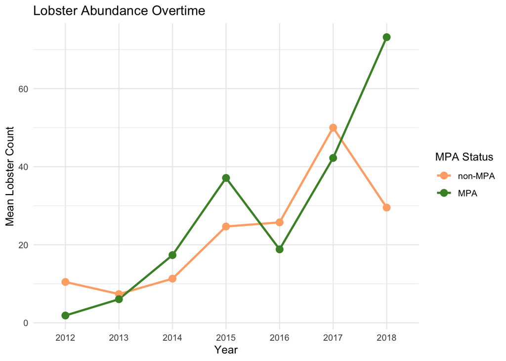

```r
# Making the dataframe
plot_counts <- ff_counts %>%
    group_by(year, treat) %>%
    summarise(mean_count = mean(obs_lob)) %>%
    ungroup()
# Plotting
plot_counts %>%
    mutate(mpa = recode(treat, # Rename mpa characters
                        `0` = "non-MPA",
                        `1` = "MPA")) %>%
    ggplot(aes(x = year, y = mean_count, color = mpa, group = mpa)) + # plot
    geom_line(linewidth = 1)+
    geom_point(size = 3) +
    scale_color_manual(values = c("#ffad76", "#488f30")) +
    theme_minimal() +
    labs(
        title = "Lobster Abundance Overtime",
        x = "Year",
        y = "Mean Lobster Count",
        color = "MPA Status"
    )
```

#### Step 8: Reconsider causal identification assumptions

1. Discuss whether you think `spillover effects` are likely in this research context (see Glossary of terms; https://docs.google.com/document/d/1RIudsVcYhWGpqC-Uftk9UTz3PIq6stVyEpT44EPNgpE/edit?usp=sharing)

Spillover is when the treatment and control outcomes can impact each other - outcomes are not independent of each other. In marine MPA situations, spillover is a factor. Marine life does not know MPA extents and therefore travel inside and outside the area, impacting lobster count in treated and non-treated areas. Spillover effects are strongest in the area surrounding the MPA. In this research, the non-MPA area are far way from MPAs which makes the spillover effect less intense.

2. Explain why spillover is an issue for the identification of causal effects.

Spillover effects make it hard to discover the causal impacts of the treatment when the outcomes depend on each other. The intermixing of outcomes makes it difficult to disguising the specific cause and effect.

**c. How does spillover relate to impact in this research setting?**

In concept, MPAs, being safe-havens for marine life, would increase fish (and lobster) biomass. Because marine life travels in and out of the MPAs, the positive effects of MPAs cross into non-MPA zones (known as spillover effect). When comparing lobster abundance in MPA and non-MPA zones, the spillover effect can add lobster counts in treated and non-treated sites, making the MPA zones look less effective than they are in reality.

4. Discuss the following causal inference assumptions in the context of the MPA treatment effect estimator. Evaluate if each of the assumption are reasonable:
   1. SUTVA: Stable Unit Treatment Value assumption
   2. ‘Exogeneity’ assumption

SUTVA has two assumptions: (1) no interference and (2) consistency. No interference is violated when the control (unprotected) group is affected by the treatment group. For biodiversity counts in MPA vs non-MPA locations, marine life from the MPAs can travel to non-protected areas, affecting the outcomes. Thus, violating the SUTVA assumption. Consistent assumption is violated as MPAs can vary in their restrictiveness. Some MPAs are no-take zones, while others have restrictions on seasons or gear, violating SUTVA’s ‘No hidden variation’ parameter. Thus, both SUTVA assumptions are not met.

Exogeneity assumption refer to the outcome error being unbiased. However, in a MPA treatment effect estimator, the error can be caused to due to MPA placement (MPA location is chosen for a specific reason - not randomly selected) or ecological covariates (depth and habitat). Therefore, both SUTVA and exogeneity assumptions can be violated when studying MPA effectiveness.

# EXTRA CREDIT

> Use the recent lobster abundance data with observations collected up until 2024 (`extracredit_sblobstrs24.csv`) to run an analysis evaluating the effect of MPA status on lobster counts using the same focal variables.
1. Create a new script for the analysis on the updated data
2. Run at least 3 regression models & assess model diagnostics
3. Compare and contrast results with the analysis from the 2012-2018 data sample (~ 2 paragraphs)